# R Notebook

For this assignment, we are going to look at the jevons dataset to analyze the relationship between the weight of coins to their age which will serve as the sole predictor variable, as always we will start off with exploratory data analysis.

```r
library(alr4)
data(jevons)
head (jevons)
```

|  | Age | n | Weight | SD | Min | Max |
| --- | --- | --- | --- | --- | --- | --- |
| 1 | 1 | 123 | 7.9725 | 0.01409 | 7.900 | 7.999 |
| 2 | 2 | 78 | 7.9503 | 0.02272 | 7.892 | 7.993 |
| 3 | 3 | 32 | 7.9276 | 0.03426 | 7.848 | 7.984 |
| 4 | 4 | 17 | 7.8962 | 0.04057 | 7.827 | 7.965 |
| 5 | 5 | 24 | 7.8730 | 0.05353 | 7.757 | 7.961 |

```r
summary(jevons)
```

```
      Age          n             Weight            SD               Min             Max
 Min.   :1   Min.   : 17.0   Min.   :7.873   Min.   :0.01409   Min.   :7.757   Min.   :7.961
 1st Qu.:2   1st Qu.: 24.0   1st Qu.:7.896   1st Qu.:0.02272   1st Qu.:7.827   1st Qu.:7.965
 Median :3   Median : 32.0   Median :7.928   Median :0.03426   Median :7.848   Median :7.984
 Mean   :3   Mean   : 54.8   Mean   :7.924   Mean   :0.03303   Mean   :7.845   Mean   :7.980
 3rd Qu.:4   3rd Qu.: 78.0   3rd Qu.:7.950   3rd Qu.:0.04057   3rd Qu.:7.892   3rd Qu.:7.993
 Max.   :5   Max.   :123.0   Max.   :7.973   Max.   :0.05353   Max.   :7.900   Max.   :7.999
```

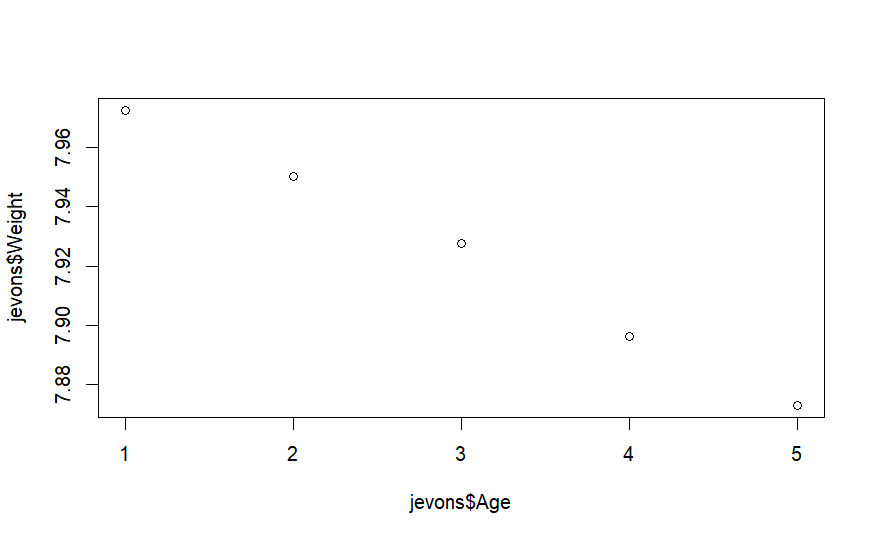

```r
plot(jevons$Age, jevons$Weight)
```

Looking at the data, it seems as if we are working with summary statistcs. This tells us that we may have to use weights in order to tackle the variance situation if we are dealing with mulitple observations for each age. We will first fit our model using only standard OLS, then we will check the model using WLS to see if it fits it better.

```r
mod <- lm(Weight~Age, data=jevons)
summary(mod)
```

```
Call:
lm(formula = Weight ~ Age, data = jevons)

Residuals:
       1        2        3        4        5
-0.00204  0.00107  0.00368 -0.00241 -0.00030

Coefficients:
              Estimate Std. Error t value Pr(>|t|)
(Intercept)  7.9998500  0.0030123 2655.74 1.18e-10 ***
Age         -0.0253100  0.0009082  -27.87 0.000101 ***
---
Signif. codes:  0 ‘***’ 0.001 ‘**’ 0.01 ‘*’ 0.05 ‘.’ 0.1 ‘ ’ 1

Residual standard error: 0.002872 on 3 degrees of freedom
Multiple R-squared:  0.9962,    Adjusted R-squared:  0.9949
F-statistic: 776.6 on 1 and 3 DF,  p-value: 0.0001014
```

```r
ncvTest(mod)
```

```
Non-constant Variance Score Test
Variance formula: ~ fitted.values
Chisquare = 0.02471857, Df = 1, p = 0.87507
```

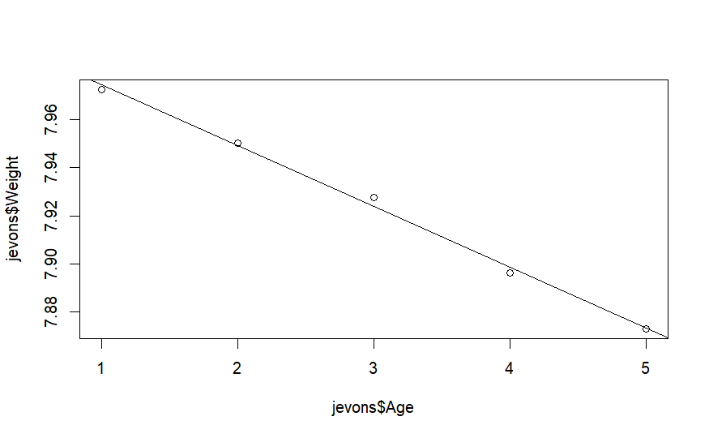

```r
plot(jevons$Age, jevons$Weight)
abline(mod)
```

We see the line going through the data, however, with this being summary statistics, we know that we are dealing with different variances at each data point of age. Although the NCV Test tells us there is homoscedasticity, we can still try to plot out the residuals against the fitted values as well.

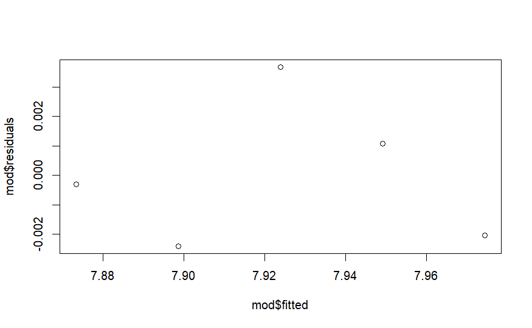

```r
plot(mod$fitted, mod$residuals)
```

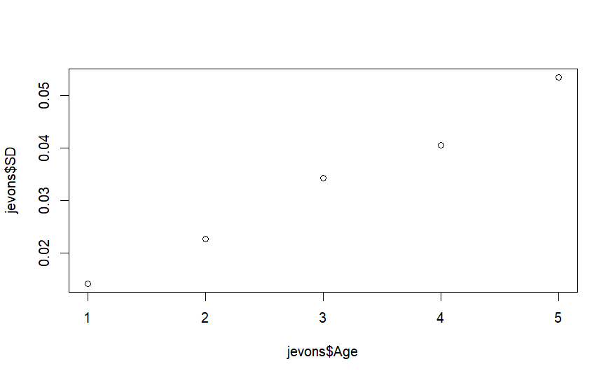

```r
plot(jevons$Age, jevons$SD)
```

It is very difficult to tell from the first plot, however the second plot shows that as age increases, the variances also increases. For the purpose of predictions, we will add weights using Weighted Least Squares because that will allow us to predict better on datapoints where there is little to no variation. Dealing with summary statistics, we want to use the inverse of the variance which for this case is variance/n, so the inverse will be n/variance.

```r
modw <- lm(Weight~Age, data=jevons, weights = n/(SD^2))
plot(jevons$Age, jevons$Weight)
abline(modw, col="black")
```

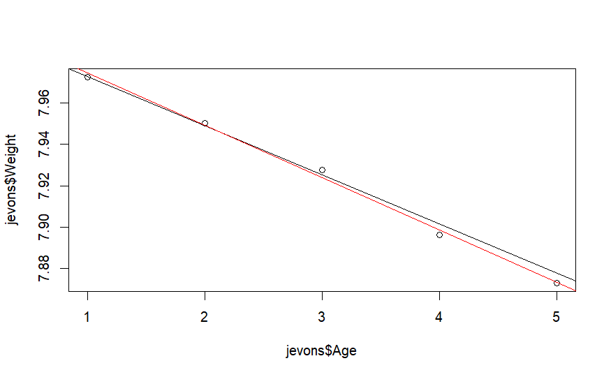

```r
abline(mod, col="red")
```

Looking at the lines from our two models, the black line is from the WLS model and the red is OLS. As stated before, weights allow for better predictions in datapoints with very little variation, so for this we can see that our predictions will be best at ages 1-2, but once we reach age 3 and above, we experience more variation.

```r
summary(mod)
```

```
Call:
lm(formula = Weight ~ Age, data = jevons)

Residuals:
       1        2        3        4        5
-0.00204  0.00107  0.00368 -0.00241 -0.00030

Coefficients:
              Estimate Std. Error t value Pr(>|t|)
(Intercept)  7.9998500  0.0030123 2655.74 1.18e-10 ***
Age         -0.0253100  0.0009082  -27.87 0.000101 ***
---
Signif. codes:  0 ‘***’ 0.001 ‘**’ 0.01 ‘*’ 0.05 ‘.’ 0.1 ‘ ’ 1

Residual standard error: 0.002872 on 3 degrees of freedom
Multiple R-squared:  0.9962,    Adjusted R-squared:  0.9949
F-statistic: 776.6 on 1 and 3 DF,  p-value: 0.0001014
```

```r
summary(modw)
```

```
Call:
lm(formula = Weight ~ Age, data = jevons, weights = n/(SD^2))

Weighted Residuals:
      1       2       3       4       5
-0.2091  0.5017  0.3875 -0.5383 -0.4339

Coefficients:
              Estimate Std. Error t value Pr(>|t|)
(Intercept)  7.9965218  0.0013220    6049 9.96e-12 ***
Age         -0.0237562  0.0008797     -27 0.000111 ***
---
Signif. codes:  0 ‘***’ 0.001 ‘**’ 0.01 ‘*’ 0.05 ‘.’ 0.1 ‘ ’ 1

Residual standard error: 0.5549 on 3 degrees of freedom
Multiple R-squared:  0.9959,    Adjusted R-squared:  0.9945
F-statistic: 729.2 on 1 and 3 DF,  p-value: 0.0001114
```

```r
data(stopping)
head(stopping)
```

|  | Speed | Distance |
| --- | --- | --- |
| 1 | 4 | 4 |
| 2 | 5 | 2 |
| 3 | 5 | 4 |
| 4 | 5 | 8 |
| 5 | 5 | 8 |
| 6 | 7 | 7 |

```r
NA
```

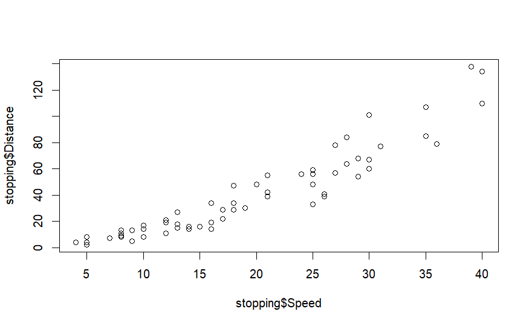

```r
plot(stopping$Speed, stopping$Distance)
```

We see evidence of a non-constant variance so we will address that, but first, we will fit the line.

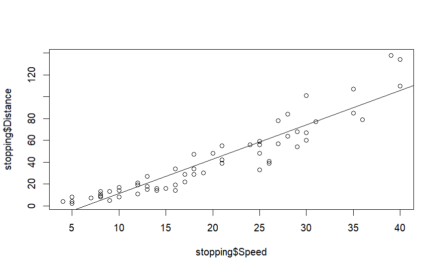

```r
stop <- lm(Distance~Speed, data = stopping)
plot(stopping$Speed, stopping$Distance)
abline(stop)
```

Our fitted line seems to fit the data pretty well, but we also suspect non-constant variance so let us look at a plot of the residuals against the fitted values.

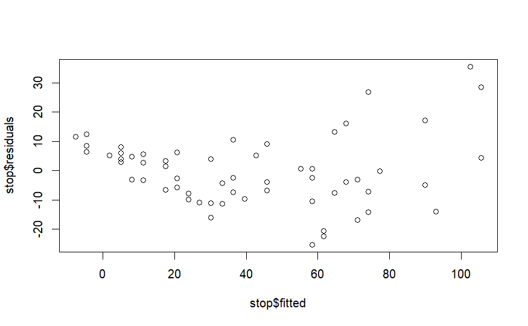

```r
plot(stop$fitted, stop$residuals)
```

```r
ncvTest(stop)
```

```
Non-constant Variance Score Test
Variance formula: ~ fitted.values
Chisquare = 20.49387, Df = 1, p = 5.9822e-06
```

With the plot looking like a slight megaphone and our test show that we do indeed have a non-constant variance. Now, we must decide how to handle this non-constant variance. Since we are only working with a single, it would be a bit difficult to figure out the variance at each point. We will try three different weights that will allow us the keep the weights positive.

```r
stop2 <- lm(Distance~Speed, data=stopping, weights = 1/abs(Speed))
stop3 <- lm(Distance~Speed, data=stopping, weights = 1/(Speed^2))
stop4 <- lm(Distance~Speed, data=stopping, weights = exp(Speed))

plot(stopping$Speed, stopping$Distance, xlab="Speed", ylab = "Distance")
abline(stop2, col="blue")
```

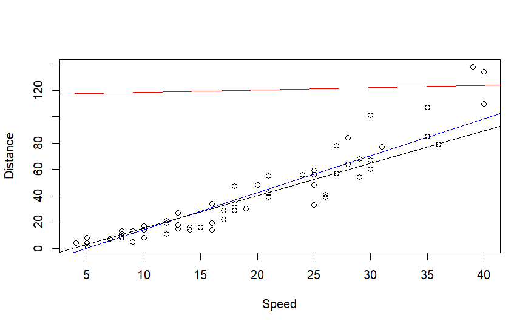

```r
abline(stop3, col="black")
abline(stop4, col="red")
```

We used three different models with different weights. The blue line corresponds to our weight using the inverse absolute value of speed. The black line uses the inverse of the square of speed. The red line is just the exponent of speed. Clearly, the red line does not fit the data at all. Therefore, we can weed that out and only focus on the inverses of the square of speed and the absolute value of speed.

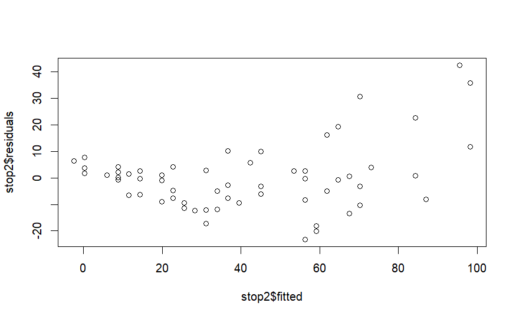

```r
plot(stop2$fitted, stop2$residuals)
```

```r
ncvTest(stop2)
```

```
Non-constant Variance Score Test
Variance formula: ~ fitted.values
Chisquare = 8.76644, Df = 1, p = 0.0030682
```

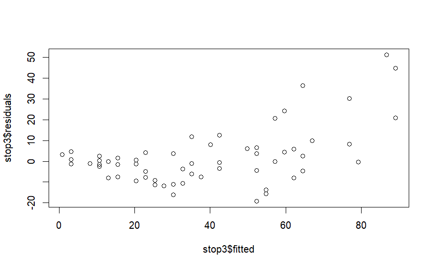

```r
plot(stop3$fitted, stop3$residuals)
```

```r
ncvTest(stop3)
```

```
Non-constant Variance Score Test
Variance formula: ~ fitted.values
Chisquare = 1.211887, Df = 1, p = 0.27096
```

The plot and the NCV Test for the inverse of the square of speed is much better as we accept the null at almost every level. Although the plot does still show a bit of a megaphone shape. For this problem, it seems as if the inverse of the square of speed is the best, so we will go with that and evaluate.

```r
summary(stop3)
```

```
Call:
lm(formula = Distance ~ Speed, data = stopping, weights = 1/(Speed^2))

Weighted Residuals:
     Min       1Q   Median       3Q      Max
-1.01336 -0.36497 -0.01549  0.29353  1.31668

Coefficients:
            Estimate Std. Error t value Pr(>|t|)
(Intercept)  -9.0458     1.4257  -6.345 3.24e-08 ***
Speed         2.4537     0.1297  18.911  < 2e-16 ***
---
Signif. codes:  0 ‘***’ 0.001 ‘**’ 0.01 ‘*’ 0.05 ‘.’ 0.1 ‘ ’ 1

Residual standard error: 0.5754 on 60 degrees of freedom
Multiple R-squared:  0.8563,    Adjusted R-squared:  0.8539
F-statistic: 357.6 on 1 and 60 DF,  p-value: < 2.2e-16
```

For our next problem we will be looking at the MinnLand data which shows the relationship of acre prices per acre for farms in Minnesota. The acre price will be our response, or acrePrice. For predictors we will use the percentage of property value due to improvements, acre size of the farm, percentage of farm acreage that is rated arable by an assessor, productivity of each farm, the year of sale of the farm, and the percentage of all farm acres enrolled in the Federal Conservation Reserve Program.

```r
data(MinnLand)
head(MinnLand)
```

|  | acrePrice | region | improvements | year | acres | tillable | financing | crpPct | productivity |
| --- | --- | --- | --- | --- | --- | --- | --- | --- | --- |
| 1 | 766 | Northwest | 0 | 2002 | 82 | 94 | title_transfer | 0 | NA |
| 2 | 733 | Northwest | 0 | 2003 | 30 | 63 | title_transfer | 0 | NA |
| 3 | 850 | Northwest | 4 | 2002 | 150 | 47 | title_transfer | 0 | NA |
| 4 | 975 | Northwest | 0 | 2003 | 160 | 86 | title_transfer | 0 | NA |
| 5 | 886 | Northwest | 62 | 2002 | 90 | NA | title_transfer | 0 | NA |
| 6 | 992 | Northwest | 30 | 2003 | 120 | 83 | title_transfer | 0 | NA |

```r
summary(MinnLand)
```

```
   acrePrice               region      improvements          year          acres           tillable
 Min.   :  108   Northwest    :3799   Min.   :  0.000   Min.   :2002   Min.   :   1.0   Min.   :  0.00
 1st Qu.: 1425   West Central :3297   1st Qu.:  0.000   1st Qu.:2004   1st Qu.:  47.0   1st Qu.: 72.00
 Median : 2442   Central      :4198   Median :  0.000   Median :2006   Median :  80.0   Median : 92.00
 Mean   : 2787   South West   :2583   Mean   :  4.493   Mean   :2006   Mean   : 112.7   Mean   : 80.67
 3rd Qu.: 3702   South Central:2832   3rd Qu.:  0.000   3rd Qu.:2008   3rd Qu.: 153.0   3rd Qu.: 97.00
 Max.   :15000   South East   :1991   Max.   :100.000   Max.   :2011   Max.   :6970.0   Max.   :100.00
                                      NA's   :50                                        NA's   :1212
           financing         crpPct         productivity
 title_transfer :16601   Min.   :  0.000   Min.   : 1.00
 seller_financed: 2099   1st Qu.:  0.000   1st Qu.:59.00
                         Median :  0.000   Median :68.00
                         Mean   :  4.163   Mean   :66.63
                         3rd Qu.:  0.000   3rd Qu.:76.00
                         Max.   :100.000   Max.   :99.00
                                           NA's   :9717
```

```r
acrefit <- lm(acrePrice~improvements+year+acres+tillable+crpPct+productivity, data=MinnLand)
summary(acrefit)
```

```
Call:
lm(formula = acrePrice ~ improvements + year + acres + tillable +
    crpPct + productivity, data = MinnLand)

Residuals:
    Min      1Q  Median      3Q     Max
-5414.6  -573.8   -85.6   429.8 10544.0

Coefficients:
               Estimate Std. Error t value Pr(>|t|)
(Intercept)  -6.809e+05  9.651e+03 -70.554  < 2e-16 ***
improvements  5.437e+01  1.403e+00  38.742  < 2e-16 ***
year          3.393e+02  4.812e+00  70.513  < 2e-16 ***
acres        -1.979e+00  1.323e-01 -14.960  < 2e-16 ***
tillable      6.687e+00  8.263e-01   8.092 6.65e-16 ***
crpPct       -9.822e+00  8.759e-01 -11.214  < 2e-16 ***
productivity  4.064e+01  9.383e-01  43.314  < 2e-16 ***
---
Signif. codes:  0 ‘***’ 0.001 ‘**’ 0.01 ‘*’ 0.05 ‘.’ 0.1 ‘ ’ 1

Residual standard error: 1087 on 8763 degrees of freedom
  (9930 observations deleted due to missingness)
Multiple R-squared:  0.5104,    Adjusted R-squared:   0.51
F-statistic:  1522 on 6 and 8763 DF,  p-value: < 2.2e-16
```

Running the model as is tells us several things. First and foremost, all the variables seem to be significant. With all things equal to 0, we can expect acre prices to be around -6.809e+05 which does not make too much sense so we see it as a tuning parameter. For every unit increase of improvements, the acre price increases by 54.37. For every increase in year, the acre price increases by 339.3. For every increase in acres we expect a decrease of 1.979 in acre prices. An increase in tillable increases acre prices by 6.687. An increase in all the farms enrolled in the National Conservation Reserve program decreases acre prices by 9.822 and finally an increase by one unit in productivity increases acre prices by 40.64. We fit our model without checking for any of our assumptions; linearity, homoscedasticity, no multicollinearity, normality, independence of errors, and no major outliers.

```r
residualPlots(acrefit)
```

```
             Test stat Pr(>|Test stat|)
improvements    5.7836        7.565e-09 ***
year            3.2447          0.00118 **
acres           9.4324        < 2.2e-16 ***
tillable        7.6048        3.148e-14 ***
crpPct          2.2462          0.02472 *
productivity   13.4941        < 2.2e-16 ***
Tukey test     20.1896        < 2.2e-16 ***
---
Signif. codes:  0 ‘***’ 0.001 ‘**’ 0.01 ‘*’ 0.05 ‘.’ 0.1 ‘ ’ 1
```

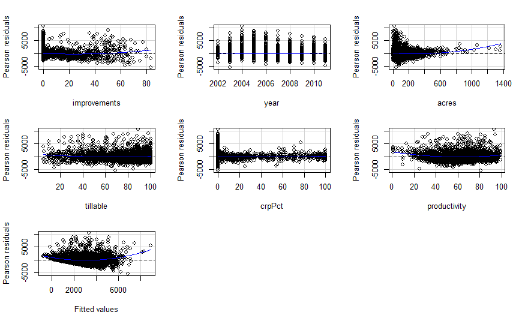

```r
par(mfrow=c(2,2))
```

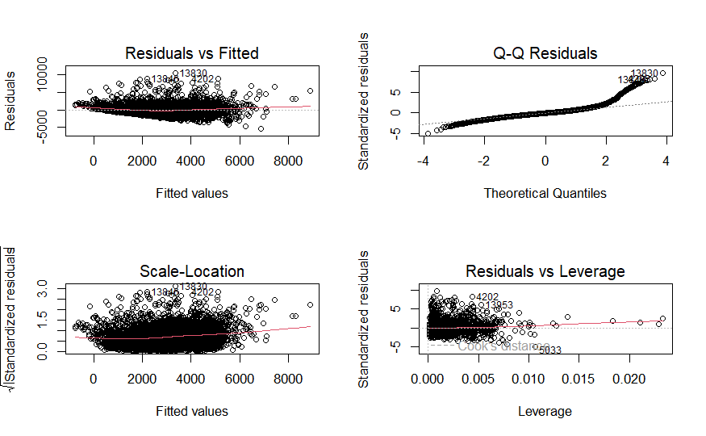

```r
plot(acrefit)
```

```r
ncvTest(acrefit)
```

```
Non-constant Variance Score Test
Variance formula: ~ fitted.values
Chisquare = 346.8355, Df = 1, p = < 2.22e-16
```

```r
outlierTest(acrefit)
```

|  | rstudent | unadjusted p-value | Bonferroni p |
| --- | --- | --- | --- |
| 13830 | 9.752752 | 2.3323e-22 | 2.0454e-18 |
| 4202 | 8.255463 | 1.7330e-16 | 1.5199e-12 |
| 13846 | 8.123208 | 5.1568e-16 | 4.5225e-12 |
| 15328 | 8.043726 | 9.8506e-16 | 8.6389e-12 |
| 13840 | 7.962849 | 1.8913e-15 | 1.6587e-11 |
| 13856 | 7.819588 | 5.9137e-15 | 5.1863e-11 |
| 4233 | 7.460543 | 9.4391e-14 | 8.2781e-10 |
| 13878 | 7.392291 | 1.5759e-13 | 1.3820e-09 |
| 13857 | 7.228721 | 5.2846e-13 | 4.6346e-09 |
| 4166 | 7.154698 | 9.0602e-13 | 7.9458e-09 |

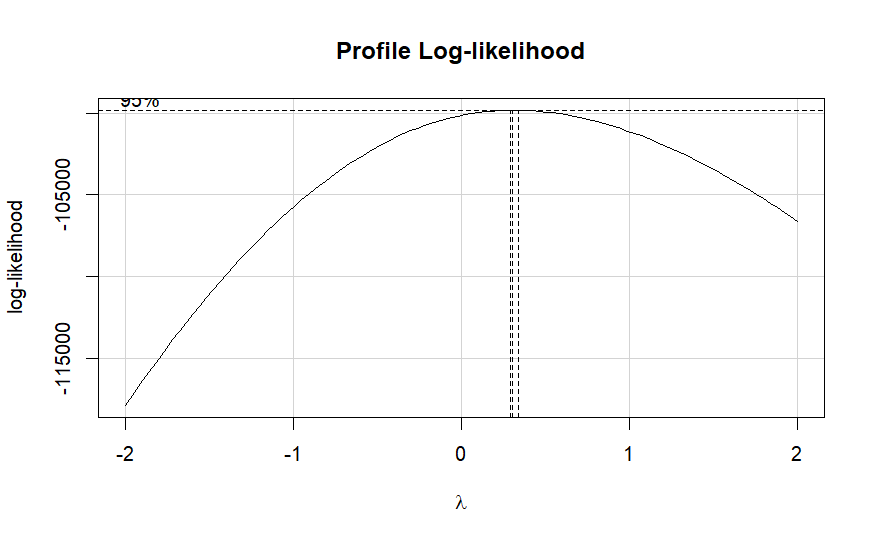

```r
boxCox(acrefit)
```

| lambda | RSS |
| --- | --- |
| 0.3234356 | 4793314766 |
| -1.0000000 | 6888616777 |
| 0.0000000 | 4922986894 |
| 1.0000000 | 5288276512 |

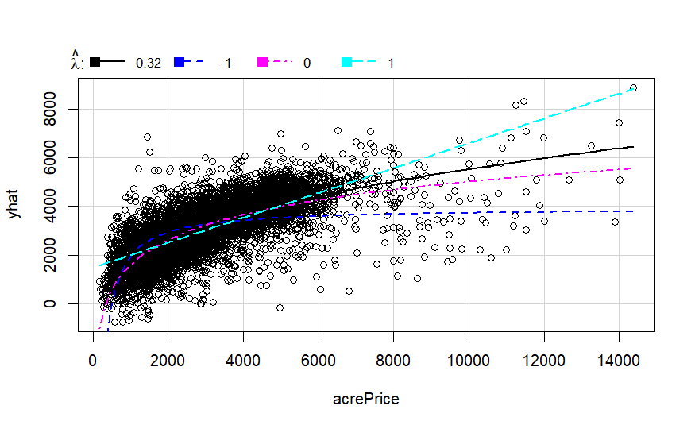

```r
invResPlot(acrefit)
```

Based on both methods a power of .32 provides the lowest residual sum of squares. The second best choice is a power transformation of 0, which we know will turn any number to 1. For data scientists, we use 0 as log. First, we will look into doing the recommended transformation for the response.

```r
acrefit2 <- lm(acrePrice^(.32)~improvements+year+acres+tillable+crpPct+productivity, data=MinnLand)
summary(acrefit2)
```

```
Call:
lm(formula = acrePrice^(0.32) ~ improvements + year + acres +
    tillable + crpPct + productivity, data = MinnLand)

Residuals:
    Min      1Q  Median      3Q     Max
-6.7417 -0.7232  0.0112  0.6903  8.5797

Coefficients:
               Estimate Std. Error t value Pr(>|t|)
(Intercept)  -9.595e+02  1.249e+01  -76.83   <2e-16 ***
improvements  6.452e-02  1.816e-03   35.53   <2e-16 ***
year          4.819e-01  6.226e-03   77.41   <2e-16 ***
acres        -2.800e-03  1.712e-04  -16.36   <2e-16 ***
tillable      1.441e-02  1.069e-03   13.48   <2e-16 ***
crpPct       -1.699e-02  1.133e-03  -14.99   <2e-16 ***
productivity  6.061e-02  1.214e-03   49.92   <2e-16 ***
---
Signif. codes:  0 ‘***’ 0.001 ‘**’ 0.01 ‘*’ 0.05 ‘.’ 0.1 ‘ ’ 1

Residual standard error: 1.407 on 8763 degrees of freedom
  (9930 observations deleted due to missingness)
Multiple R-squared:  0.5633,    Adjusted R-squared:  0.563
F-statistic:  1884 on 6 and 8763 DF,  p-value: < 2.2e-16
```

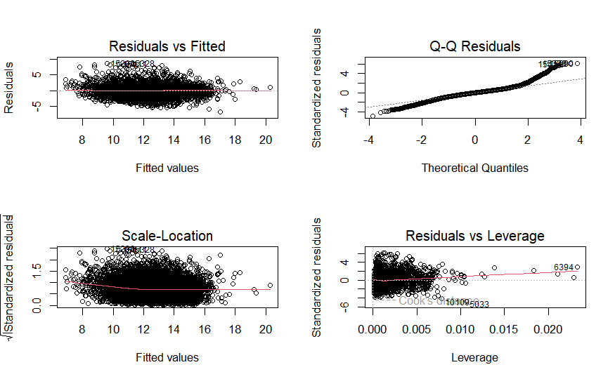

```r
par(mfrow=c(2,2))
plot(acrefit2)
```

```r
ncvTest(acrefit2)
```

```
Non-constant Variance Score Test
Variance formula: ~ fitted.values
Chisquare = 276.9367, Df = 1, p = < 2.22e-16
```

```r
outlierTest(acrefit2)
```

|  | rstudent | unadjusted p-value | Bonferroni p |
| --- | --- | --- | --- |
| 15290 | 6.114509 | 1.0100e-09 | 8.8574e-06 |
| 15328 | 6.055649 | 1.4561e-09 | 1.2770e-05 |
| 15411 | 5.934305 | 3.0630e-09 | 2.6862e-05 |
| 13846 | 5.892445 | 3.9457e-09 | 3.4604e-05 |
| 15157 | 5.770626 | 8.1662e-09 | 7.1618e-05 |
| 4166 | 5.750380 | 9.2029e-09 | 8.0709e-05 |
| 2792 | 5.723111 | 1.0803e-08 | 9.4744e-05 |
| 13830 | 5.675384 | 1.4278e-08 | 1.2522e-04 |
| 15248 | 5.661144 | 1.5511e-08 | 1.3603e-04 |
| 4233 | 5.510027 | 3.6895e-08 | 3.2357e-04 |

```
             Test stat Pr(>|Test stat|)
improvements    4.1885        2.835e-05 ***
year           -2.6504         0.008055 **
acres           9.9601        < 2.2e-16 ***
tillable        8.5455        < 2.2e-16 ***
crpPct          0.6551         0.512410
productivity   11.3013        < 2.2e-16 ***
Tukey test      7.3920        1.447e-13 ***
---
Signif. codes:  0 ‘***’ 0.001 ‘**’ 0.01 ‘*’ 0.05 ‘.’ 0.1 ‘ ’ 1
```

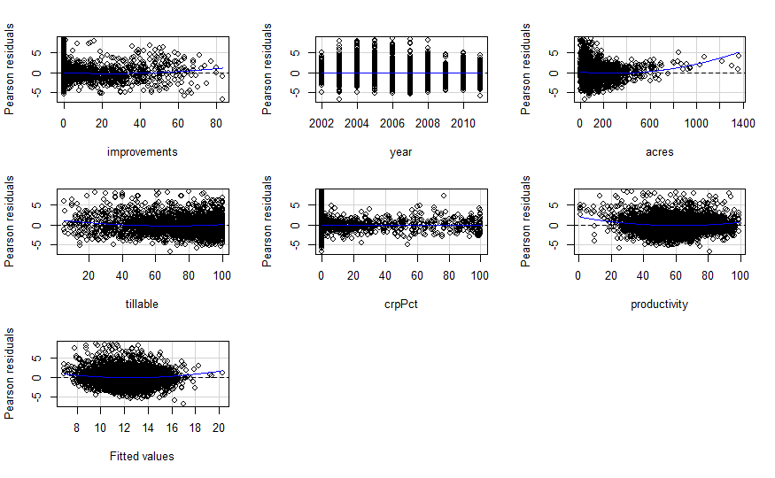

```r
residualPlots(acrefit2)
```

With the recommended transformation, our coefficient estimates change drastically, but still move in the same directions with unit increases of each variable. We still see non-constant variance and we still a violation of normality as well as linearity. Not only that, we loose interpretability with an exponent like that. In fact this makes everything even harder. Let’s try the other recommended power transformation as a log transformation can be interpreted.

```r
acrefit3 <- lm(log(acrePrice)~improvements+year+acres+tillable+crpPct+productivity, data=MinnLand)
summary(acrefit3)
```

```
Call:
lm(formula = log(acrePrice) ~ improvements + year + acres + tillable +
    crpPct + productivity, data = MinnLand)

Residuals:
     Min       1Q   Median       3Q      Max
-1.95388 -0.16523  0.02142  0.18413  1.98717

Coefficients:
               Estimate Std. Error t value Pr(>|t|)
(Intercept)  -2.376e+02  3.248e+00  -73.15   <2e-16 ***
improvements  1.536e-02  4.723e-04   32.53   <2e-16 ***
year          1.216e-01  1.619e-03   75.12   <2e-16 ***
acres        -7.221e-04  4.452e-05  -16.22   <2e-16 ***
tillable      4.334e-03  2.781e-04   15.59   <2e-16 ***
crpPct       -4.768e-03  2.947e-04  -16.18   <2e-16 ***
productivity  1.587e-02  3.157e-04   50.28   <2e-16 ***
---
Signif. codes:  0 ‘***’ 0.001 ‘**’ 0.01 ‘*’ 0.05 ‘.’ 0.1 ‘ ’ 1

Residual standard error: 0.3659 on 8763 degrees of freedom
  (9930 observations deleted due to missingness)
Multiple R-squared:  0.5585,    Adjusted R-squared:  0.5582
F-statistic:  1847 on 6 and 8763 DF,  p-value: < 2.2e-16
```

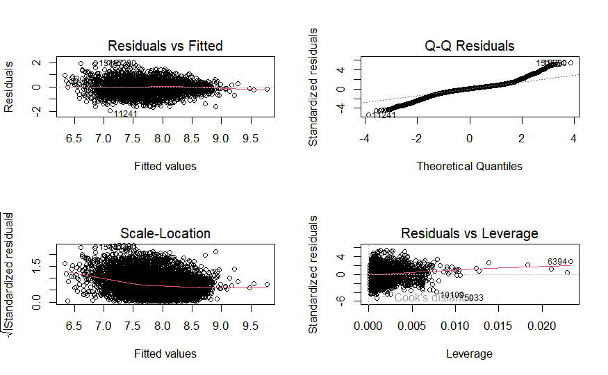

```r
par(mfrow=c(2,2))
plot(acrefit3)
```

```r
ncvTest(acrefit3)
```

```
Non-constant Variance Score Test
Variance formula: ~ fitted.values
Chisquare = 1177.959, Df = 1, p = < 2.22e-16
```

```r
outlierTest(acrefit3)
```

|  | rstudent | unadjusted p-value | Bonferroni p |
| --- | --- | --- | --- |
| 15290 | 5.443475 | 5.3663e-08 | 0.00047062 |
| 15157 | 5.404270 | 6.6782e-08 | 0.00058568 |
| 11241 | -5.350938 | 8.9710e-08 | 0.00078676 |
| 2848 | 5.218665 | 1.8435e-07 | 0.00161670 |
| 15411 | 5.217367 | 1.8564e-07 | 0.00162800 |
| 2792 | 5.116588 | 3.1771e-07 | 0.00278630 |
| 15389 | 5.109444 | 3.2992e-07 | 0.00289340 |
| 15328 | 5.046996 | 4.5783e-07 | 0.00401520 |
| 4166 | 4.920893 | 8.7720e-07 | 0.00769300 |
| 15248 | 4.896881 | 9.9111e-07 | 0.00869200 |

```
             Test stat Pr(>|Test stat|)
improvements    3.4403        0.0005838 ***
year           -5.6018        2.185e-08 ***
acres           9.7673        < 2.2e-16 ***
tillable        8.2020        2.698e-16 ***
crpPct         -0.4711        0.6376064
productivity    9.0869        < 2.2e-16 ***
Tukey test      0.0668        0.9467309
---
Signif. codes:  0 ‘***’ 0.001 ‘**’ 0.01 ‘*’ 0.05 ‘.’ 0.1 ‘ ’ 1
```

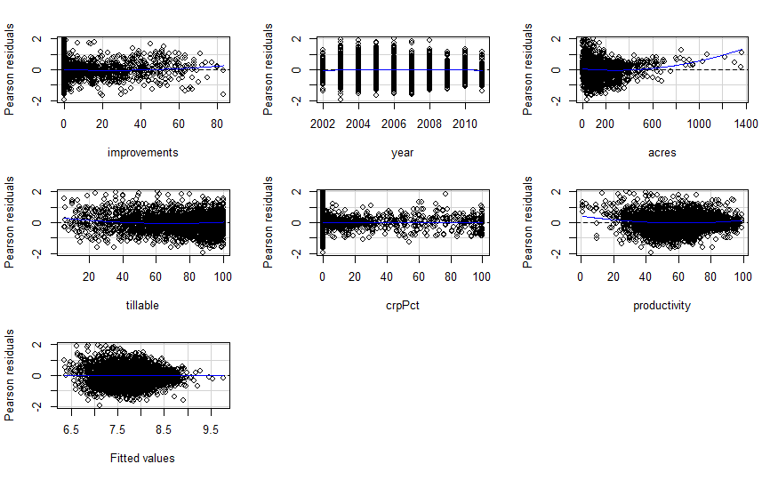

```r
residualPlots(acrefit3)
```

We are still seeing some violations, especially with the non-constant variance. Our overall model shows linearity, however there are several predictors that do not. Usually, the global passing the linearity check is fine, but for better inferences we also want to address the predictors. Normality is still violated as well. Now, to try to address those, we can see about doing a transformation for the rest of the predictors.

```r
summary(powerTransform(cbind(acrePrice, improvements, year, acres, tillable, crpPct, productivity)~1, MinnLand, family="bcnPower"))
```

```
bcnPower transformation to Multinormality

Estimated power, lambda
             Est Power Rounded Pwr Wald Lwr Bnd Wald Upr Bnd
acrePrice       0.3017       0.302       0.2769       0.3265
improvements   -1.5226      -1.523      -1.5553      -1.4898
year           -2.2974      -2.297      -2.3064      -2.2883
acres          -0.0070       0.000      -0.0326       0.0186
tillable        3.0000       3.000       2.9077       3.0923
crpPct         -2.0639      -2.064      -2.1073      -2.0206
productivity    1.8637       1.864       1.7569       1.9705

Estimated location, gamma
             Est gamma Std Err. Wald Lower Bound Wald Upper Bound
acrePrice       0.1000       NA               NA               NA
improvements    0.1000       NA               NA               NA
year         1276.6003       NA               NA               NA
acres          27.0890       NA               NA               NA
tillable       18.9633       NA               NA               NA
crpPct          0.1000       NA               NA               NA
productivity   68.9190       NA               NA               NA

Likelihood ratio tests about transformation parameters
```

|  | LRT | df | pval |
| --- | --- | --- | --- |
| LR test, lambda = (0 0 0 0 0 0 0) | 60146.6 | 7 | 0 |
| LR test, lambda = (1 1 1 1 1 1 1) | 210694.9 | 7 | 0 |

Now we are seeing some transformation recommendations and some may lead to some interpretability issues. Normally, I would just use the log of acre prices and the log of acres as well since that was its actual recommendation, however, we will actually go with the recommended lambdas. Also, for certain transformations such as negative exponents and 0-exponent, we have to make sure we do not see any 0’s for that particular variable or it will cause us problems when using logs or negative powers.

```r
MinnLand$improvements2 <- MinnLand$improvements + 1
MinnLand$crpPct2 <- MinnLand$crpPct + 1

acrefit4 <- lm(acrePrice^(.302)~I(improvements2^(-1.523))+I(year^(-2.297))+log(acres)+I(tillable^3)+I(crpPct2^(-2.064))+I(productivity^(1.864)), data = MinnLand)
summary(acrefit4)
```

```
Call:
lm(formula = acrePrice^(0.302) ~ I(improvements2^(-1.523)) +
    I(year^(-2.297)) + log(acres) + I(tillable^3) + I(crpPct2^(-2.064)) +
    I(productivity^(1.864)), data = MinnLand)

Residuals:
    Min      1Q  Median      3Q     Max
-4.5907 -0.6319  0.0196  0.6007  6.7516

Coefficients:
                            Estimate Std. Error t value Pr(>|t|)
(Intercept)                3.477e+02  4.583e+00   75.86   <2e-16 ***
I(improvements2^(-1.523)) -1.018e+00  4.399e-02  -23.14   <2e-16 ***
I(year^(-2.297))          -1.298e+10  1.766e+08  -73.52   <2e-16 ***
log(acres)                -4.004e-01  1.822e-02  -21.97   <2e-16 ***
I(tillable^3)              7.086e-07  5.612e-08   12.63   <2e-16 ***
I(crpPct2^(-2.064))        5.136e-01  4.861e-02   10.57   <2e-16 ***
I(productivity^(1.864))    7.599e-04  1.521e-05   49.98   <2e-16 ***
---
Signif. codes:  0 ‘***’ 0.001 ‘**’ 0.01 ‘*’ 0.05 ‘.’ 0.1 ‘ ’ 1

Residual standard error: 1.185 on 8763 degrees of freedom
  (9930 observations deleted due to missingness)
Multiple R-squared:  0.5381,    Adjusted R-squared:  0.5378
F-statistic:  1701 on 6 and 8763 DF,  p-value: < 2.2e-16
```

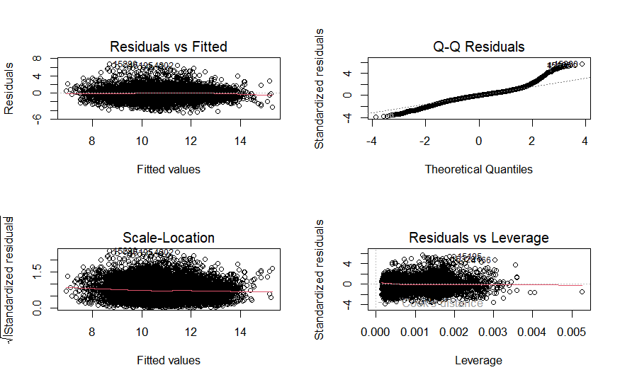

```r
par(mfrow=c(2,2))
plot(acrefit4)
```

```r
ncvTest(acrefit4)
```

```
Non-constant Variance Score Test
Variance formula: ~ fitted.values
Chisquare = 142.8045, Df = 1, p = < 2.22e-16
```

```r
outlierTest(acrefit4)
```

|  | rstudent | unadjusted p-value | Bonferroni p |
| --- | --- | --- | --- |
| 15290 | 5.708871 | 1.1743e-08 | 0.00010299 |
| 15195 | 5.478404 | 4.4107e-08 | 0.00038682 |
| 4202 | 5.449435 | 5.1901e-08 | 0.00045517 |
| 15198 | 5.377952 | 7.7279e-08 | 0.00067774 |
| 13846 | 5.346407 | 9.1976e-08 | 0.00080663 |
| 13857 | 5.270485 | 1.3930e-07 | 0.00122170 |
| 2792 | 5.193055 | 2.1152e-07 | 0.00185500 |
| 4245 | 5.151155 | 2.6452e-07 | 0.00231990 |
| 4168 | 5.147370 | 2.6990e-07 | 0.00236700 |
| 14937 | 5.084337 | 3.7655e-07 | 0.00330230 |

```
                          Test stat Pr(>|Test stat|)
I(improvements2^(-1.523))   11.9954        < 2.2e-16 ***
I(year^(-2.297))            -2.4241         0.015368 *
log(acres)                  -2.0631         0.039128 *
I(tillable^3)                5.7452        9.487e-09 ***
I(crpPct2^(-2.064))         -6.6397        3.329e-11 ***
I(productivity^(1.864))     -3.0363         0.002402 **
Tukey test                  -3.2135         0.001311 **
---
Signif. codes:  0 ‘***’ 0.001 ‘**’ 0.01 ‘*’ 0.05 ‘.’ 0.1 ‘ ’ 1
```

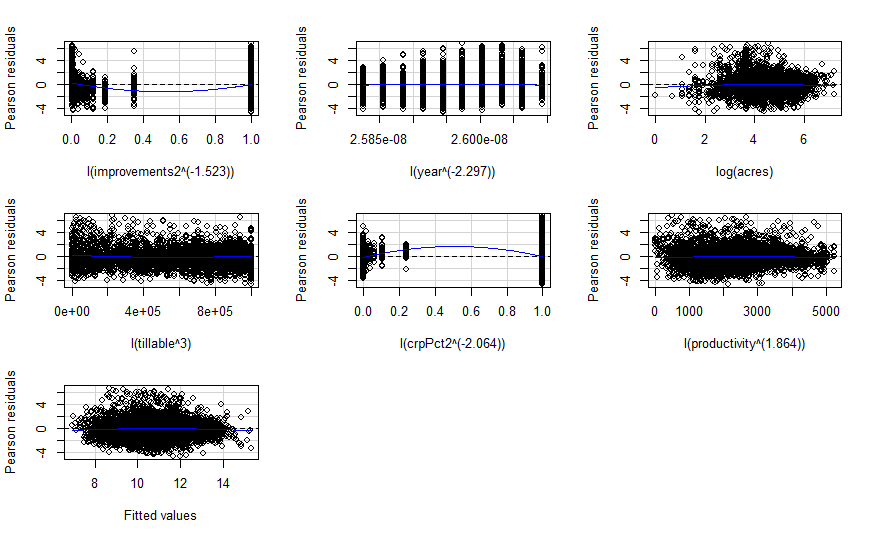

```r
residualPlots(acrefit4)
```

Finally, I am going to use the transformation that I felt was more appropriate for the sake of being able to interpret the relationship. I will use a log transformation for both acre price and acres.

```r
acrefit5 <- lm(log(acrePrice)~improvements+year+log(acres)+tillable+crpPct+productivity, data=MinnLand)
summary(acrefit5)
```

```
Call:
lm(formula = log(acrePrice) ~ improvements + year + log(acres) +
    tillable + crpPct + productivity, data = MinnLand)

Residuals:
     Min       1Q   Median       3Q      Max
-1.99102 -0.16360  0.02388  0.18988  2.01479

Coefficients:
               Estimate Std. Error t value Pr(>|t|)
(Intercept)  -2.364e+02  3.226e+00  -73.27   <2e-16 ***
improvements  1.538e-02  4.688e-04   32.81   <2e-16 ***
year          1.212e-01  1.608e-03   75.40   <2e-16 ***
log(acres)   -1.098e-01  5.528e-03  -19.86   <2e-16 ***
tillable      4.620e-03  2.771e-04   16.67   <2e-16 ***
crpPct       -4.658e-03  2.927e-04  -15.91   <2e-16 ***
productivity  1.588e-02  3.133e-04   50.70   <2e-16 ***
---
Signif. codes:  0 ‘***’ 0.001 ‘**’ 0.01 ‘*’ 0.05 ‘.’ 0.1 ‘ ’ 1

Residual standard error: 0.3633 on 8763 degrees of freedom
  (9930 observations deleted due to missingness)
Multiple R-squared:  0.5648,    Adjusted R-squared:  0.5645
F-statistic:  1895 on 6 and 8763 DF,  p-value: < 2.2e-16
```

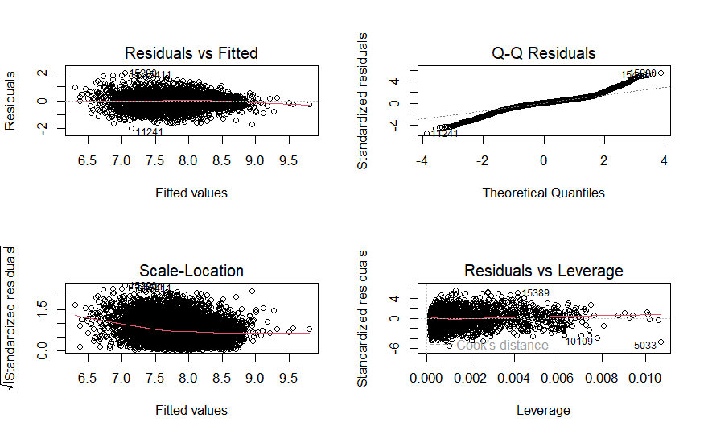

```r
par(mfrow=c(2,2))
plot(acrefit5)
```

```r
ncvTest(acrefit5)
```

```
Non-constant Variance Score Test
Variance formula: ~ fitted.values
Chisquare = 932.8187, Df = 1, p = < 2.22e-16
```

```r
outlierTest(acrefit5)
```

|  | rstudent | unadjusted p-value | Bonferroni p |
| --- | --- | --- | --- |
| 15290 | 5.559561 | 2.7839e-08 | 0.00024415 |
| 11241 | -5.492900 | 4.0646e-08 | 0.00035646 |
| 15411 | 5.197621 | 2.0641e-07 | 0.00181020 |
| 15389 | 5.095190 | 3.5566e-07 | 0.00311910 |
| 15157 | 5.049458 | 4.5199e-07 | 0.00396400 |
| 2848 | 4.920105 | 8.8073e-07 | 0.00772400 |
| 2792 | 4.915876 | 8.9991e-07 | 0.00789220 |
| 15268 | 4.914665 | 9.0547e-07 | 0.00794100 |
| 15248 | 4.912143 | 9.1717e-07 | 0.00804350 |
| 15267 | 4.854821 | 1.2258e-06 | 0.01075000 |

```
             Test stat Pr(>|Test stat|)
improvements    2.7042         0.006860 **
year           -5.8112        6.421e-09 ***
log(acres)     -1.5162         0.129495
tillable        8.2768        < 2.2e-16 ***
crpPct         -0.8678         0.385528
productivity    8.8092        < 2.2e-16 ***
Tukey test     -2.8093         0.004966 **
---
Signif. codes:  0 ‘***’ 0.001 ‘**’ 0.01 ‘*’ 0.05 ‘.’ 0.1 ‘ ’ 1
```

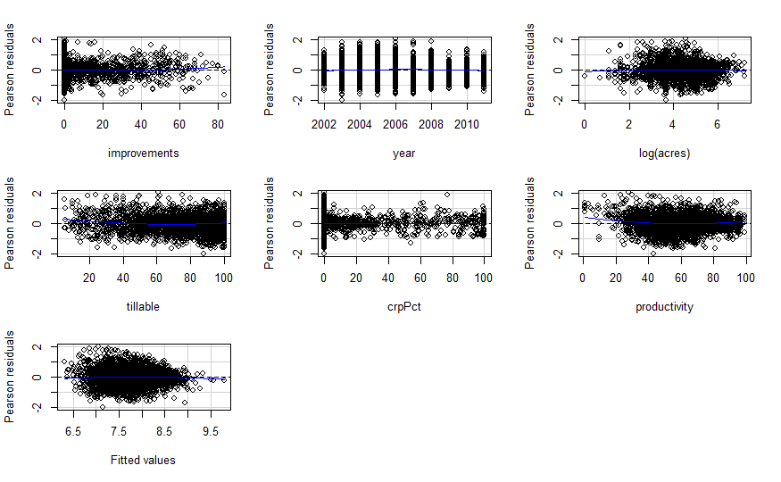

```r
residualPlots(acrefit5)
```

For the last problem we will look at a data set pertaining to the 2000 election. Each observation consists of a county in Florida and the amount of votes they gave for each Presidential candidate, so all of this data is for Florida. There are three variables, “Bush”, “Buchanan”, “Gore”; we will use Bush as the response and just Buchanan as the predictor to look at the relationship of those who voted for Bush to those who voted for Buchanan. We will start with exploratory data analysis.

```r
data(florida)
head(florida)
```

|  | Gore | Bush | Buchanan |
| --- | --- | --- | --- |
| ALACHUA | 47300 | 34062 | 262 |
| BAKER | 2392 | 5610 | 73 |
| BAY | 18850 | 38637 | 248 |
| BRADFORD | 3072 | 5413 | 65 |
| BREVARD | 97318 | 115185 | 570 |
| BROWARD | 386518 | 177279 | 789 |

```r
summary(florida)
```

```
      Gore             Bush           Buchanan
 Min.   :   788   Min.   :  1316   Min.   :   9.0
 1st Qu.:  3055   1st Qu.:  4746   1st Qu.:  46.5
 Median : 14152   Median : 20196   Median : 114.0
 Mean   : 43341   Mean   : 43356   Mean   : 258.5
 3rd Qu.: 45974   3rd Qu.: 56542   3rd Qu.: 285.5
 Max.   :386518   Max.   :289456   Max.   :3407.0
```

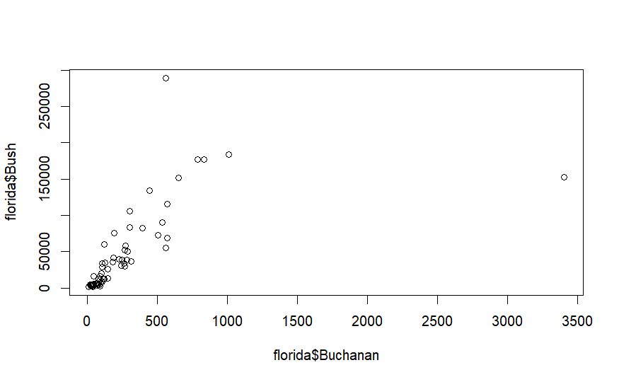

```r
plot(florida$Buchanan, florida$Bush)
```

Looking at the data and the chart, it may be suitable for us to do some sort of transformation on the response and predictor because the range goes over several orders of 10. Before doing that, we will go ahead and fit the model.

```r
vote <- lm(Bush~Buchanan, data=florida)
summary(vote)
```

```
Call:
lm(formula = Bush ~ Buchanan, data = florida)

Residuals:
    Min      1Q  Median      3Q     Max
-139562  -21969  -13626    4156  222169

Coefficients:
            Estimate Std. Error t value Pr(>|t|)
(Intercept)  22911.1     6338.8   3.614 0.000588 ***
Buchanan        79.1       12.3   6.432 1.73e-08 ***
---
Signif. codes:  0 ‘***’ 0.001 ‘**’ 0.01 ‘*’ 0.05 ‘.’ 0.1 ‘ ’ 1

Residual standard error: 44890 on 65 degrees of freedom
Multiple R-squared:  0.3889,    Adjusted R-squared:  0.3795
F-statistic: 41.37 on 1 and 65 DF,  p-value: 1.727e-08
```

Looking at the data, it tells us that with the predictor being 0, Bush would have received 2,2911 votes. Of course we always use the intercept as a tuning parameter. For every increase in vote for Buchanan, there is a 79.1 increase in votes for Bush.

```r
ncvTest(vote)
```

```
Non-constant Variance Score Test
Variance formula: ~ fitted.values
Chisquare = 82.37916, Df = 1, p = < 2.22e-16
```

```r
outlierTest(vote)
```

|  | rstudent | unadjusted p-value | Bonferroni p |
| --- | --- | --- | --- |
| PALM BEACH | -10.150936 | 5.8269e-15 | 3.9041e-13 |
| DADE | 6.332671 | 2.7122e-08 | 1.8172e-06 |

```r
residualPlots(vote)
```

```
           Test stat Pr(>|Test stat|)
Buchanan     -10.173        5.343e-15 ***
Tukey test   -10.173        < 2.2e-16 ***
---
Signif. codes:  0 ‘***’ 0.001 ‘**’ 0.01 ‘*’ 0.05 ‘.’ 0.1 ‘ ’ 1
```

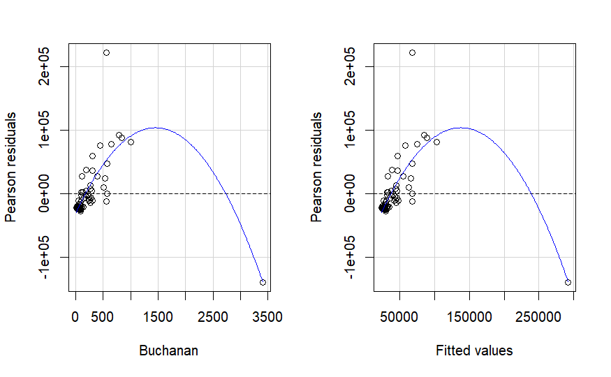

```r
par(mfrow=c(2,2))
```

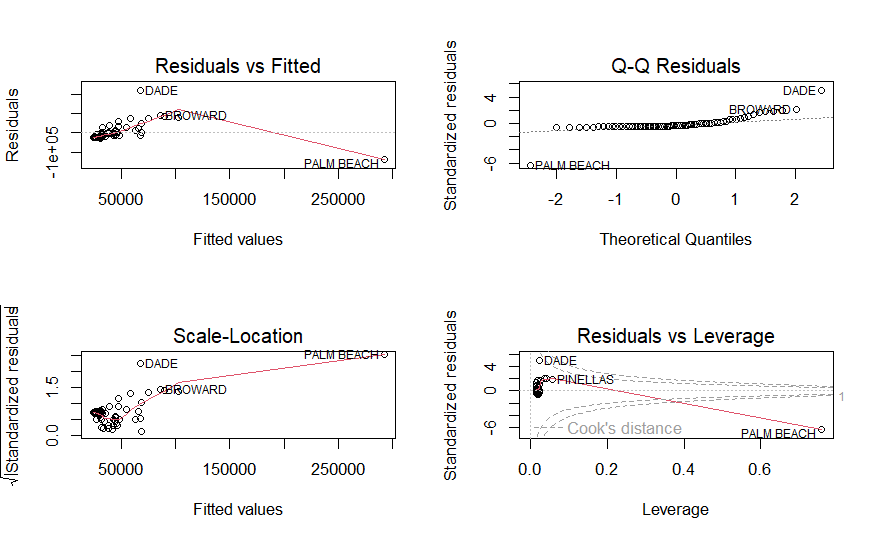

```r
plot(vote)
```

Looking at the diagnostic tests, we fail several assumptions. We have heteroscedasticity and we do not have linearity. Normality is slightly off. We also see a leverage point for Palm Beach on the x space, this one is above the value of 1 in cook’s distance. Dade is also an outlier as it too has a very low Bonferroni p-value is very small. We will see what transforming only the predictor does and see if that fixes any linearity or variance issues.

| lambda | RSS |
| --- | --- |
| 0.304032 | 74781697929 |
| -1.000000 | 172296736120 |
| 0.000000 | 86847885198 |
| 1.000000 | 130986364631 |

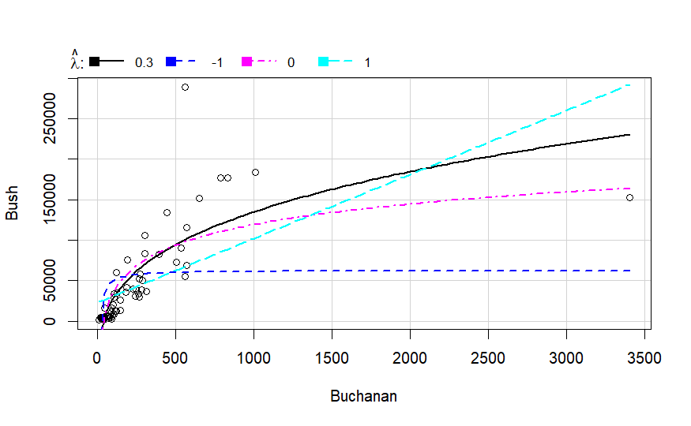

```r
invTranPlot(Bush~Buchanan, data=florida)
```

The best exponent that was recommended to us was for .304. We know that is not very easy to explain, so we will go with the next best one which is a log transformation on the variable Buchanan.

```r
vote2 <- lm(Bush~log(Buchanan), data=florida)
summary(vote2)
```

```
Call:
lm(formula = Bush ~ log(Buchanan), data = florida)

Residuals:
   Min     1Q Median     3Q    Max
-43103 -23107  -8138  13525 191348

Coefficients:
              Estimate Std. Error t value Pr(>|t|)
(Intercept)    -133643      18661  -7.162 8.98e-10 ***
log(Buchanan)    36613       3748   9.769 2.24e-14 ***
---
Signif. codes:  0 ‘***’ 0.001 ‘**’ 0.01 ‘*’ 0.05 ‘.’ 0.1 ‘ ’ 1

Residual standard error: 36550 on 65 degrees of freedom
Multiple R-squared:  0.5948,    Adjusted R-squared:  0.5886
F-statistic: 95.43 on 1 and 65 DF,  p-value: 2.24e-14
```

```r
ncvTest(vote2)
```

```
Non-constant Variance Score Test
Variance formula: ~ fitted.values
Chisquare = 19.87657, Df = 1, p = 8.2607e-06
```

```r
outlierTest(vote2)
```

|  | rstudent | unadjusted p-value | Bonferroni p |
| --- | --- | --- | --- |
| DADE | 7.06882 | 1.4087e-09 | 9.4382e-08 |

```r
residualPlots(vote2)
```

```
              Test stat Pr(>|Test stat|)
log(Buchanan)    3.9845        0.0001758 ***
Tukey test       3.9845        6.762e-05 ***
---
Signif. codes:  0 ‘***’ 0.001 ‘**’ 0.01 ‘*’ 0.05 ‘.’ 0.1 ‘ ’ 1
```

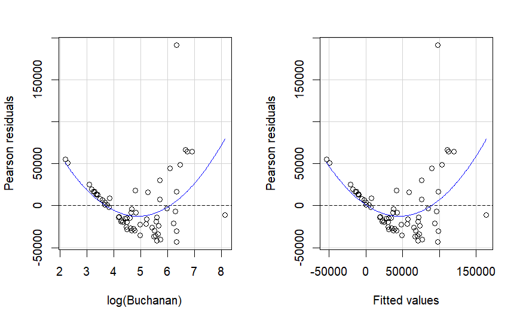

```r
par(mfrow=c(2,2))
```

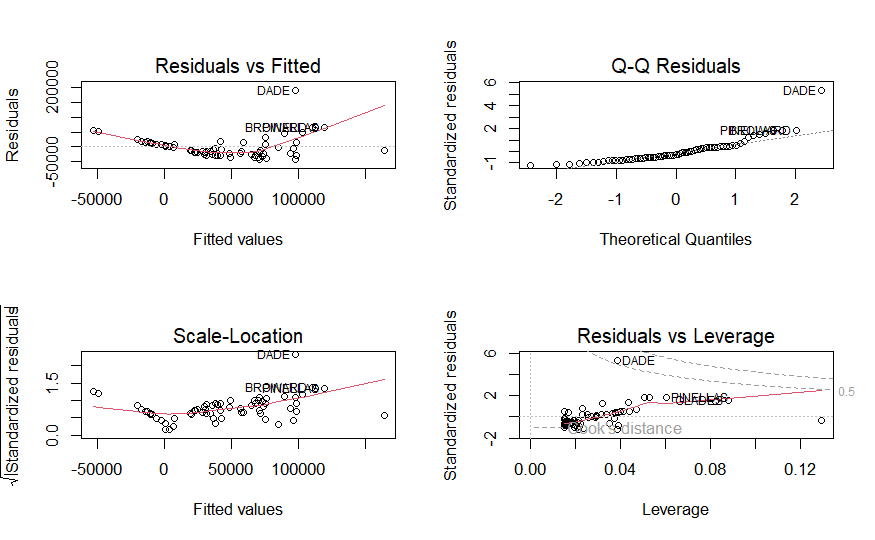

```r
plot(vote2)
```

The transformation allowed us to eliminate Palm Beach as an outlier, but that was about the only thing that was fixed. Perhaps the normality assumption was fixed a bit, but we still have a non-constant variance, we don’t have linearity and Dad remains an outlier, though maybe not too influential as it lies between 1 and 0.5 of cook’s distance. Let us see about transforming all variables to address normality, variance and possibly the linearity assumption.

```r
summary(powerTransform(cbind(Bush, Buchanan)~1, florida))
```

```
bcPower Transformations to Multinormality
         Est Power Rounded Pwr Wald Lwr Bnd Wald Upr Bnd
Bush       -0.0030           0      -0.1359       0.1299
Buchanan   -0.0401           0      -0.1456       0.0653

Likelihood ratio test that transformation parameters are equal to 0
 (all log transformations)
```

|  | LRT | df | pval |
| --- | --- | --- | --- |
| LR test, lambda = (0 0) | 0.644426 | 2 | 0.72454 |

```
Likelihood ratio test that no transformations are needed
```

|  | LRT | df | pval |
| --- | --- | --- | --- |
| LR test, lambda = (1 1) | 347.1268 | 2 | < 2.22e-16 |

The power transformation suggests that we do a log transformation for both the predictor and the response. This excellent because a long transformation is very easy to interpret.

```r
vote3 <- lm(log(Bush)~log(Buchanan), data = florida)
summary(vote3)
```

```
Call:
lm(formula = log(Bush) ~ log(Buchanan), data = florida)

Residuals:
     Min       1Q   Median       3Q      Max
-1.54850 -0.30867 -0.00458  0.30312  1.26199

Coefficients:
              Estimate Std. Error t value Pr(>|t|)
(Intercept)    4.35314    0.29039   14.99   <2e-16 ***
log(Buchanan)  1.12282    0.05832   19.25   <2e-16 ***
---
Signif. codes:  0 ‘***’ 0.001 ‘**’ 0.01 ‘*’ 0.05 ‘.’ 0.1 ‘ ’ 1

Residual standard error: 0.5688 on 65 degrees of freedom
Multiple R-squared:  0.8508,    Adjusted R-squared:  0.8485
F-statistic: 370.6 on 1 and 65 DF,  p-value: < 2.2e-16
```

```r
ncvTest(vote3)
```

```
Non-constant Variance Score Test
Variance formula: ~ fitted.values
Chisquare = 0.9078992, Df = 1, p = 0.34067
```

```r
outlierTest(vote3)
```

```
No Studentized residuals with Bonferroni p < 0.05
Largest |rstudent|:
```

|  | rstudent | unadjusted p-value | Bonferroni p |
| --- | --- | --- | --- |
| PALM BEACH | -3.105483 | 0.00283 | 0.18961 |

```r
residualPlots(vote3)
```

```
              Test stat Pr(>|Test stat|)
log(Buchanan)   -0.8069           0.4227
Tukey test      -0.8069           0.4197
```

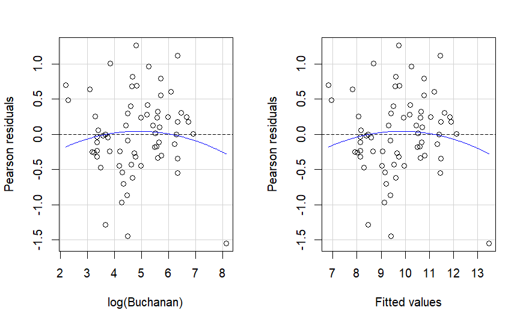

```r
par(mfrow=c(2,2))
```

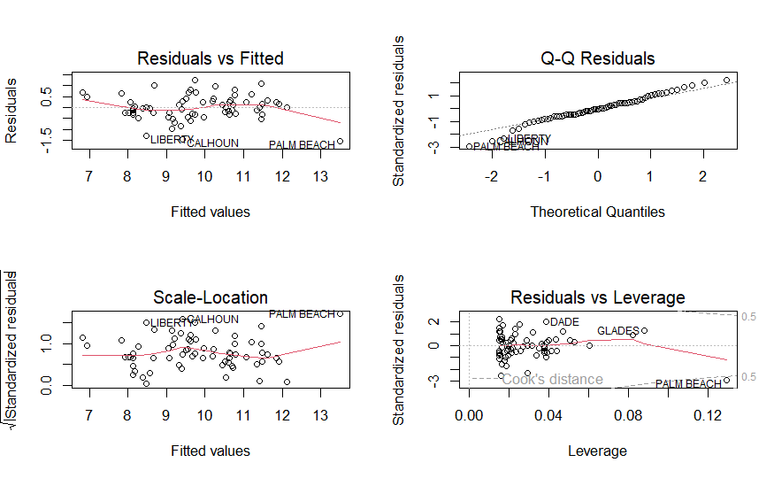

```r
plot(vote3)
```

```r
which(rownames(florida) == "PALM BEACH")
```

```
[1] 50
```

```r
voteless <- lm(log(Bush)~log(Buchanan), data=florida[-50,])
summary(voteless)
```

```
Call:
lm(formula = log(Bush) ~ log(Buchanan), data = florida[-50, ])

Residuals:
     Min       1Q   Median       3Q      Max
-1.44841 -0.27972  0.00887  0.28175  1.23731

Coefficients:
              Estimate Std. Error t value Pr(>|t|)
(Intercept)    4.08144    0.28650   14.25   <2e-16 ***
log(Buchanan)  1.18451    0.05828   20.32   <2e-16 ***
---
Signif. codes:  0 ‘***’ 0.001 ‘**’ 0.01 ‘*’ 0.05 ‘.’ 0.1 ‘ ’ 1

Residual standard error: 0.5344 on 64 degrees of freedom
Multiple R-squared:  0.8658,    Adjusted R-squared:  0.8637
F-statistic:   413 on 1 and 64 DF,  p-value: < 2.2e-16
```

```r
summary(vote3)
```

```
Call:
lm(formula = log(Bush) ~ log(Buchanan), data = florida)

Residuals:
     Min       1Q   Median       3Q      Max
-1.54850 -0.30867 -0.00458  0.30312  1.26199

Coefficients:
              Estimate Std. Error t value Pr(>|t|)
(Intercept)    4.35314    0.29039   14.99   <2e-16 ***
log(Buchanan)  1.12282    0.05832   19.25   <2e-16 ***
---
Signif. codes:  0 ‘***’ 0.001 ‘**’ 0.01 ‘*’ 0.05 ‘.’ 0.1 ‘ ’ 1

Residual standard error: 0.5688 on 65 degrees of freedom
Multiple R-squared:  0.8508,    Adjusted R-squared:  0.8485
F-statistic: 370.6 on 1 and 65 DF,  p-value: < 2.2e-16
```